# PA1_template.html

SPN

Thursday, September 04, 2014

Step 1. Download raw data and save as cvs

```r
url<-"http://d396qusza40orc.cloudfront.net/repdata%2Fdata%2Factivity.zip"

download.file(url, destfile = "activity.zip", mode="wb")
unzip("activity.zip", files = NULL, list = FALSE, overwrite = TRUE,
      junkpaths = FALSE, exdir = ".", unzip = "internal",
      setTimes = FALSE)
raw = read.csv("activity.csv", header=TRUE, row.names=NULL,
 stringsAsFactors=FALSE)
```

Step 2. Loading and preprocessing the data show any code that is needed to Load the data (i.e. read.csv()). Examine that data to determine what is needed. There are more than 570,000 steps in the dataset but many NAs

```r
sum(raw$steps,na.rm=TRUE)# 570,608 steps
```

```
## [1] 570608
```

```r
summary(raw)#strongly skewed data with more than half of the step counts zero
```

```
##      steps           date              interval
##  Min.   :  0.0   Length:17568       Min.   :   0
##  1st Qu.:  0.0   Class :character   1st Qu.: 589
##  Median :  0.0   Mode  :character   Median :1178
##  Mean   : 37.4                      Mean   :1178
##  3rd Qu.: 12.0                      3rd Qu.:1766
##  Max.   :806.0                      Max.   :2355
##  NA's   :2304
```

```r
#initial count of NAs is 2304"
summary(is.na(raw$steps)) # na totals totals
```

```
##    Mode   FALSE    TRUE    NA's
## logical   15264    2304       0
```

```r
with(raw,table(is.na(raw$steps), raw$date))#by date note some days have all nas
```

```
##
##         2012-10-01 2012-10-02 2012-10-03 2012-10-04 2012-10-05 2012-10-06
##   FALSE          0        288        288        288        288        288
##   TRUE         288          0          0          0          0          0
##
##         2012-10-07 2012-10-08 2012-10-09 2012-10-10 2012-10-11 2012-10-12
##   FALSE        288          0        288        288        288        288
##   TRUE           0        288          0          0          0          0
##
##         2012-10-13 2012-10-14 2012-10-15 2012-10-16 2012-10-17 2012-10-18
##   FALSE        288        288        288        288        288        288
##   TRUE           0          0          0          0          0          0
##
##         2012-10-19 2012-10-20 2012-10-21 2012-10-22 2012-10-23 2012-10-24
##   FALSE        288        288        288        288        288        288
##   TRUE           0          0          0          0          0          0
##
##         2012-10-25 2012-10-26 2012-10-27 2012-10-28 2012-10-29 2012-10-30
##   FALSE        288        288        288        288        288        288
##   TRUE           0          0          0          0          0          0
##
##         2012-10-31 2012-11-01 2012-11-02 2012-11-03 2012-11-04 2012-11-05
##   FALSE        288          0        288        288          0        288
##   TRUE           0        288          0          0        288          0
##
##         2012-11-06 2012-11-07 2012-11-08 2012-11-09 2012-11-10 2012-11-11
##   FALSE        288        288        288          0          0        288
##   TRUE           0          0          0        288        288          0
##
##         2012-11-12 2012-11-13 2012-11-14 2012-11-15 2012-11-16 2012-11-17
##   FALSE        288        288          0        288        288        288
##   TRUE           0          0        288          0          0          0
##
##         2012-11-18 2012-11-19 2012-11-20 2012-11-21 2012-11-22 2012-11-23
##   FALSE        288        288        288        288        288        288
##   TRUE           0          0          0          0          0          0
##
##         2012-11-24 2012-11-25 2012-11-26 2012-11-27 2012-11-28 2012-11-29
##   FALSE        288        288        288        288        288        288
##   TRUE           0          0          0          0          0          0
##
##         2012-11-30
##   FALSE          0
##   TRUE         288
```

```r
#plot(raw$interval,raw$steps) #exploratory graphics note discontinuity separating hours.
```

```r
ti<-rep(c("00:","01:", "02:","03:", "04:", "05:","06:", "07:","08:", "09:", "10:","11:", "12:","13:", "14:", "15:","16:", "17:","18:", "19:","20:","21:", "22:","23:"), each=12)
me<-rep(c("00:00", "05:00","10:00","15:00","20:00","25:00", "30:00","35:00","40:00","45:00","50:00","55:00"), 24)
ti_me<-paste(ti,me,sep="",collapse=NULL)
time<-rep(ti_me,61)
#time[1:24]
raw1<-cbind(raw,time)
raw1$time<-as.character(raw1$time)
#interval should be a factor since it isn't a continuous variable
raw1$interval<-as.factor(raw1$interval)
#plot(raw1$interval,raw1$steps)
#summary(raw1)
```

Add date variable changing from character to date format, add a logical vector to distinguish weekends from week days.

```r
require(lubridate)
date1<-as.Date(raw1$date)
day<-wday(date1, label = TRUE, abbr = TRUE)
raw1_2<-cbind(date1,day,raw1)
raw1_2$weekend<-raw1_2$day=="Sun" | raw1_2$day=="Sat" #weekend thus = TRUE
raw1_2$weekend<-as.factor(raw1_2$weekend)
levels(raw1_2$weekend)[levels(raw1_2$weekend)=="TRUE"] <- "Weekend"
levels(raw1_2$weekend)[levels(raw1_2$weekend)=="FALSE"] <- "Weekday"
```

Create a new dataframe to eliminate 0’s. Now there are over 13,000 NAs

```r
raw2<-raw1_2
raw2$steps[raw2$steps==0] <- NA #turn zeros into na.
summary(raw2)# there are now 13,318 nas
```

```
##      date1               day           steps           date
##  Min.   :2012-10-01   Sun  :2304   Min.   :  1     Length:17568
##  1st Qu.:2012-10-16   Mon  :2592   1st Qu.: 25     Class :character
##  Median :2012-10-31   Tues :2592   Median : 56     Mode  :character
##  Mean   :2012-10-31   Wed  :2592   Mean   :134
##  3rd Qu.:2012-11-15   Thurs:2592   3rd Qu.:147
##  Max.   :2012-11-30   Fri  :2592   Max.   :806
##                       Sat  :2304   NA's   :13318
##     interval         time              weekend
##  0      :   61   Length:17568       Weekday:12960
##  5      :   61   Class :character   Weekend: 4608
##  10     :   61   Mode  :character
##  15     :   61
##  20     :   61
##  25     :   61
##  (Other):17202
```

Output 1 What is mean total number of steps taken per day? For this part of the assignment, you can ignore the missing values in the dataset. Make a histogram of the total number of steps taken each day. Note: histogram is called as a barchart as it is to show totals steps.

```r
require(plyr)
```

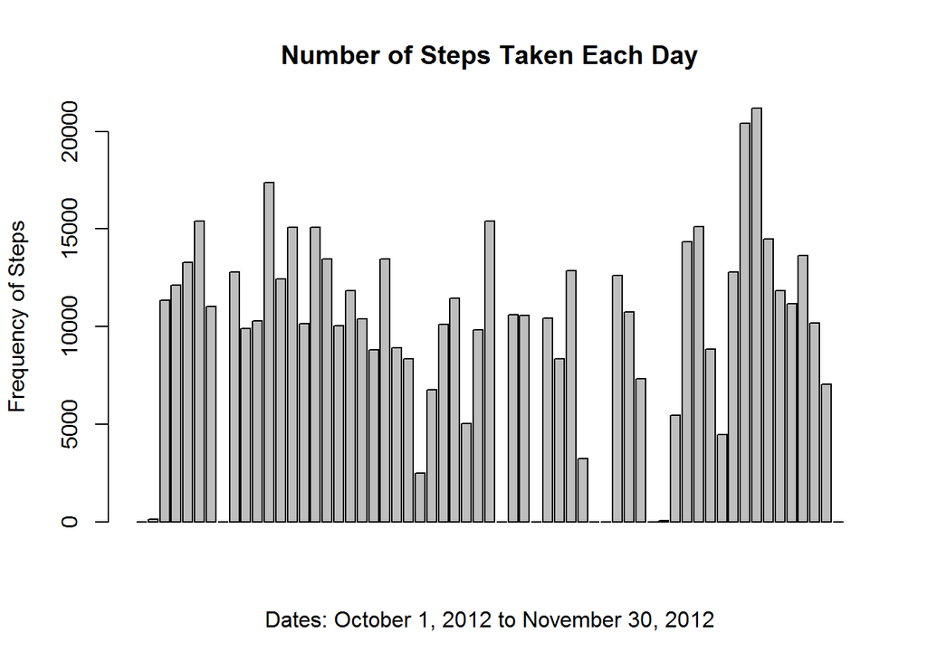

```r
daysteps<-aggregate(raw2$steps, by=list(raw2$date), "sum", na.rm=TRUE)
barplot(daysteps$x, xlab="Dates: October 1, 2012 to November 30, 2012", ylab="Frequency of Steps", main="Number of Steps Taken Each Day")
```

Calculate and report the mean and median total number of steps taken per day

```r
daystepsmean<-aggregate(raw2$steps, by=list(raw2$date), "mean", na.rm=TRUE)
daystepsmedian<-aggregate(raw2$steps, by=list(raw2$date), "median", na.rm=TRUE)
day_mean_med<-cbind(daystepsmean,daystepsmedian[2])
names(day_mean_med)<-c("date", "meansteps", "mediansteps")
day_mean_med
```

```
##          date meansteps mediansteps
## 1  2012-10-01       NaN          NA
## 2  2012-10-02     63.00        63.0
## 3  2012-10-03    140.15        61.0
## 4  2012-10-04    121.16        56.5
## 5  2012-10-05    154.58        66.0
## 6  2012-10-06    145.47        67.0
## 7  2012-10-07    101.99        52.5
## 8  2012-10-08       NaN          NA
## 9  2012-10-09    134.85        48.0
## 10 2012-10-10     95.19        56.5
## 11 2012-10-11    137.39        35.0
## 12 2012-10-12    156.59        46.0
## 13 2012-10-13    119.48        45.5
## 14 2012-10-14    160.62        60.5
```

[output cut: 47 more lines]

Make a time series plot (i.e. type = “l”) of the 5-minute interval (x-axis) and the average number of steps taken, averaged across all days (y-axis).

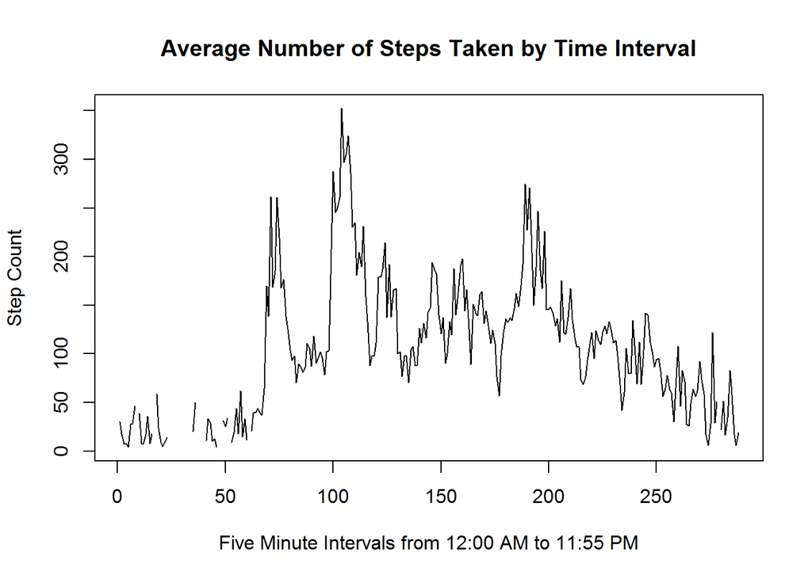

```r
require(plyr)
dailysteps<-aggregate(raw2$steps, by=list(raw2$time), "mean", na.rm=TRUE)
plot(dailysteps[,2], type="l", ylab="Step Count", xlab="Five Minute Intervals from 12:00 AM to 11:55 PM", main="Average Number of Steps Taken by Time Interval")
```

Which 5-minute interval, on average across all the days in the dataset, contains the maximum number of steps? Answer: 8:35 am

```r
names(dailysteps)<-c("Time_24hrFormat", "Steps")
highest<-dailysteps[with(dailysteps, order(-Steps)),]
head(highest,1) #am
```

```
##     Time_24hrFormat Steps
## 104        08:35:00 352.5
```

Archive to be safe, if you don’t want to do this just rename raw 2 as raw3.

```r
write.csv(raw2, "activitypart1.csv", row.names=FALSE)
```

Clean up structure of dataframe. Weekend is made a factor, as required in the second part of the assignment.

```r
raw3<-read.csv("activitypart1.csv", header=TRUE, stringsAsFactors=FALSE)
raw3$date1<-as.Date(raw3$date1)
raw3$weekend<-as.factor(raw3$weekend)
levels(raw3$weekend)[levels(raw3$weekend)=="TRUE"] <- "Weekend"
levels(raw3$weekend)[levels(raw3$weekend)=="FALSE"] <- "Weekday"
raw3$day<-as.factor(raw3$day)
raw3$interval<-as.factor(raw3$interval)
```

Imputing missing values

Note that there are a number of days/intervals where there are missing values (coded as NA). The presence of missing days may introduce bias into some calculations or summaries of the data.

Calculate and report the total number of missing values in the dataset (i.e. the total number of rows with NAs)

```r
summary(is.na(raw3$steps)) # na totals totals
```

```
##    Mode   FALSE    TRUE    NA's
## logical    4250   13318       0
```

```r
#mean(raw3$steps, na.rm=TRUE)
#a<-with(raw3,table(is.na(raw3$steps), raw3$date))#by date note some days have all nas
#a
#c<-with(raw3,table(is.na(raw3$steps), raw3$interval))
#c
#e<-as.data.frame.matrix(c)

#d<-as.data.frame.matrix(with(raw3,table(is.na(raw3$steps), raw3$interval)))
```

Devise a strategy for filling in all of the missing values in the dataset. The strategy does not need to be sophisticated. For example, you could use the mean/median for that day, or the mean for that 5-minute interval, etc.

Create a new dataset that is equal to the original dataset but with the missing data filled in.

Strategy for filling in missing values. Missing values are to be expected with these device measures as a person’s movements my not be determined to be “walking by the device algorithms. The other options include more sedentary activities sitting, laying, and standing. Also, the person may not be wearing the device. Given the pattern of some days having very high NA’s and the desire to eliminate zero’s from the pattern, this missing value strategy first sets the NA’s to 1 and then sets the dates with high proportions of NA’s to the NA average across observations. First set the 13,000 plus NA’s to one.

```r
raw3$steps[is.na(raw3$steps)] <- 1
summary(raw3$steps)
```

```
##    Min. 1st Qu.  Median    Mean 3rd Qu.    Max.
##     1.0     1.0     1.0    33.2     1.0   806.0
```

```r
raw3$steps[raw3$date=="2012-10-01"]<-raw3$steps[raw3$date=="2012-10-01"] +33
raw3$steps[raw3$date=="2012-10-02"]<-raw3$steps[raw3$date=="2012-10-02"] +33
raw3$steps[raw3$date=="2012-10-08"]<-raw3$steps[raw3$date=="2012-10-08"] +33
raw3$steps[raw3$date=="2012-10-25"]<-raw3$steps[raw3$date=="2012-10-25"] +33
raw3$steps[raw3$date=="2012-10-29"]<-raw3$steps[raw3$date=="2012-10-29"] +33
raw3$steps[raw3$date=="2012-11-01"]<-raw3$steps[raw3$date=="2012-11-01"] +33
raw3$steps[raw3$date=="2012-11-04"]<-raw3$steps[raw3$date=="2012-11-04"] +33
raw3$steps[raw3$date=="2012-11-08"]<-raw3$steps[raw3$date=="2012-11-08"] +33
raw3$steps[raw3$date=="2012-11-09"]<-raw3$steps[raw3$date=="2012-11-09"] +33
raw3$steps[raw3$date=="2012-11-10"]<-raw3$steps[raw3$date=="2012-11-10"] +33
raw3$steps[raw3$date=="2012-11-14"]<-raw3$steps[raw3$date=="2012-11-14"] +33
raw3$steps[raw3$date=="2012-11-15"]<-raw3$steps[raw3$date=="2012-11-15"] +33
raw3$steps[raw3$date=="2012-11-30"]<-raw3$steps[raw3$date=="2012-11-30"] +33
summary(raw3$steps)
```

```
##    Min. 1st Qu.  Median    Mean 3rd Qu.    Max.
##     1.0     1.0     1.0    40.3    34.0   806.0
```

Make a histogram of the total number of steps taken each day and Calculate and report the mean and median total number of steps taken per day.

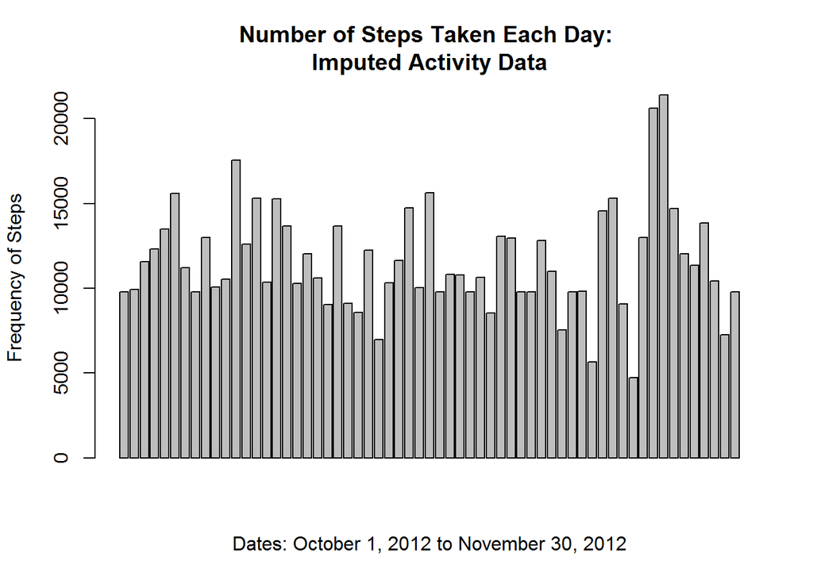

```r
require(plyr)
daysteps1<-aggregate(raw3$steps, by=list(raw3$date), "sum", na.rm=TRUE)
barplot(daysteps1$x, xlab="Dates: October 1, 2012 to November 30, 2012", ylab="Frequency of Steps", main="Number of Steps Taken Each Day: \nImputed Activity Data")
```

```r
daysteps1
```

```
##       Group.1     x
## 1  2012-10-01  9792
## 2  2012-10-02  9916
## 3  2012-10-03 11559
## 4  2012-10-04 12304
## 5  2012-10-05 13496
## 6  2012-10-06 15602
## 7  2012-10-07 11195
## 8  2012-10-08  9792
## 9  2012-10-09 13004
## 10 2012-10-10 10084
## 11 2012-10-11 10517
## 12 2012-10-12 17559
## 13 2012-10-13 12610
## 14 2012-10-14 15292
```

[output cut: 47 more lines]

Do these values differ from the estimates from the first part of the assignment? What is the impact of imputing missing data on the estimates of the total daily number of steps? The major impact is to eliminate the days with very low step counts or no step counts.

```r
daystepsmean1<-aggregate(raw3$steps, by=list(raw3$date), "mean", na.rm=TRUE)
daystepsmedian1<-aggregate(raw3$steps, by=list(raw3$date), "median", na.rm=TRUE)
daystepsmean1$x<-round(daystepsmean1$x,0)
day_mean_med1<-cbind(daystepsmean1,daystepsmedian1[2])
names(day_mean_med1)<-c("date", "adj_meansteps", "adj_mediansteps")
day_mean_med_combined<-cbind(day_mean_med,day_mean_med1[,c(2,3)])
day_mean_med_combined
```

```
##          date meansteps mediansteps adj_meansteps adj_mediansteps
## 1  2012-10-01       NaN          NA            34              34
## 2  2012-10-02     63.00        63.0            34              34
## 3  2012-10-03    140.15        61.0            40               1
## 4  2012-10-04    121.16        56.5            43               1
## 5  2012-10-05    154.58        66.0            47               1
## 6  2012-10-06    145.47        67.0            54               1
## 7  2012-10-07    101.99        52.5            39               1
## 8  2012-10-08       NaN          NA            34              34
## 9  2012-10-09    134.85        48.0            45               1
## 10 2012-10-10     95.19        56.5            35               1
## 11 2012-10-11    137.39        35.0            37               1
## 12 2012-10-12    156.59        46.0            61               1
## 13 2012-10-13    119.48        45.5            44               1
## 14 2012-10-14    160.62        60.5            53               1
```

[output cut: 47 more lines]

Are there differences in activity patterns between weekdays and weekends?

For this part the weekdays() function may be of some help here. Use the dataset with the filled-in missing values for this part.

Create a new factor variable in the dataset with two levels – “weekday” and “weekend” indicating whether a given date is a weekday or weekend day. Make a panel plot containing a time series plot (i.e. type = “l”) of the 5-minute interval (x-axis) and the average number of steps taken, averaged across all weekday days or weekend days (y-axis).

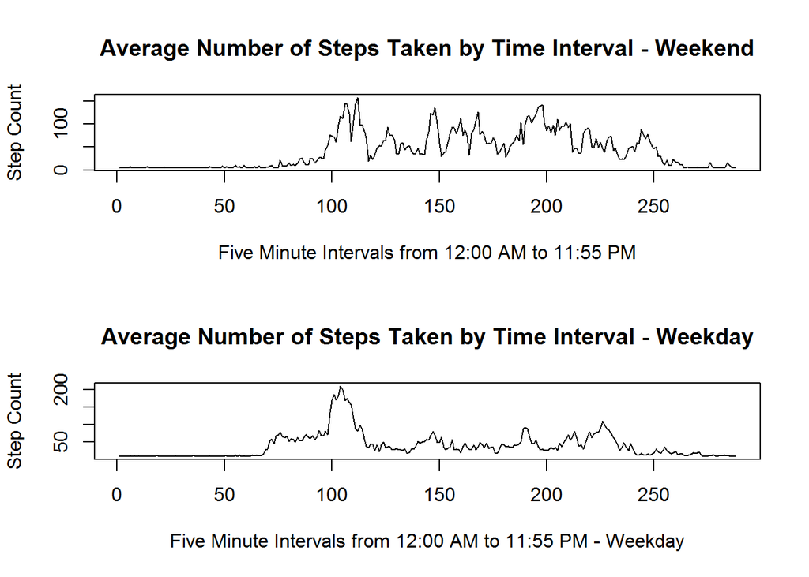

```r
dailysteps1<-aggregate(raw3$steps, by=list(raw3$weekend,raw3$time), "mean", na.rm=TRUE)
par(mfrow=c(2,1))
plot(dailysteps1$x[dailysteps1$Group.1=="Weekend"], type="l", ylab="Step Count", xlab="Five Minute Intervals from 12:00 AM to 11:55 PM", main="Average Number of Steps Taken by Time Interval - Weekend")
plot(dailysteps1$x[dailysteps1$Group.1=="Weekday"], type="l", ylab="Step Count", xlab="Five Minute Intervals from 12:00 AM to 11:55 PM - Weekday", main="Average Number of Steps Taken by Time Interval - Weekday")
```

### **Conclusion**

Comparing the plots, it is clear that weekday movement is more clustered before the work day begins and probably reflecting more sitting at ones desk during the rest of the day.

Weekend movement is more variable throughout the day and starts later in the day.